# Reproducible data reports with Quarto

Rhian Davies & Nicola Rennie

## Getting set up

- Go to the welcome page quarto.jumpingrivers.training/welcome/
- Enter your e-mail address and password **papaya-guava**
- Make a note of your username and password
- Log in at [quarto.jumpingrivers.training](https://quarto.jumpingrivers.training/)

We’ll get started when the countdown finishes.

`05:00`

# Introduction to Quarto

Quarto let’s us write documents that combine code with text. It works for multiple languages and multiple output formats. Let’s explore the Quarto [gallery](https://quarto.org/docs/gallery/).

## What about R Markdown?

R Markdown isn’t going anywhere but…

- Quarto has better multi-language support
- More user-friendly
- Better control of the output layouts

## It’s not an R package but…

```r
library(quarto)
quarto_render("document.qmd")
```

## Creating a new Quarto document

- File > New File > Quarto Document
- Set title and author
- Click **Create**
- Save and click **Render**

## YAML header

```yaml
---
title: "A very cool title"
format: html
---
```

## Content

- Text
- Links
- Images
- Code
- Embedded tables and plots
- Equations
- References

Then click the **Render** button.

## Including links

Check out the [Quarto documentation](https://quarto.org/).

## Including images

There are different ways to add images to a Quarto document. The easiest way is to use the Visual editor - click **Insert –> Figure/Image**

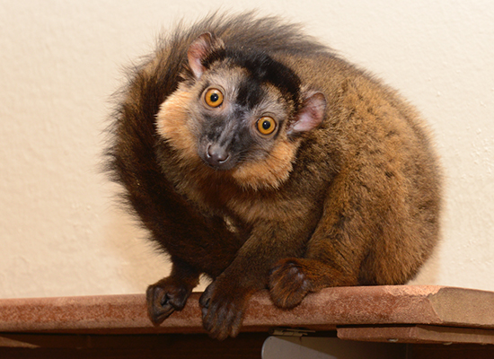

Image from Duke Lemur Center

## Task 1: Your first Quarto document

- File > New File > Quarto Document
- Set title and author
- Click **Create**
- Save and click **Render**
- Add the text from `task1.txt`
- Add a link to the Duke Lemur Center https://lemur.duke.edu/
- Add an image of the Mongoose Lemur

`15:00`

# Code Chunks

… and lemurs…

## Loading data

You can load in your data:

````markdown
```{r}
#| label: load_data
#| message: false
#| cache: true
lemurs <- readr::read_csv('https://raw.githubusercontent.com/rfordatascience/tidytuesday/master/data/2021/2021-08-24/lemur_data.csv')
```
````

## Chunk Options

- Hide the code

```yaml
#| echo: false
```

- Show the code

```yaml
#| echo: true
```

- Show the code and the YAML

```yaml
#| echo: fenced
```

## Code collapsing

We can also load in some R packages. But maybe, we collapse the code…

````markdown
```{r}
#| label: pkgs
#| message: false
#| code-fold: true
library(dplyr)
library(tidyr)
library(stringr)
library(ggplot2)
library(gghighlight)
```
````

… do some data wrangling, and print the output as a table…

````markdown
```{r}
#| label: wrangling
#| output-location: slide
df = lemurs %>%
  filter(taxon == "ECOL",
         age_category == "young_adult") %>%
  select(name, weight_g, sex, age_at_wt_mo) %>%
  filter(sex %in% c("M", "F")) %>%
  drop_na()

df %>%
  head() %>%
  knitr::kable()
```
````

| name | weight_g | sex | age_at_wt_mo |
| --- | --- | --- | --- |
| NICOLE | 2170.0 | F | 31.33 |
| ALAIN | 2502.0 | M | 22.98 |
| ALAIN | 1637.5 | M | 30.58 |
| ALAIN | 2243.0 | M | 37.22 |
| GASTON | 1916.0 | M | 37.87 |
| GASTON | 2147.5 | M | 38.30 |

…or include some exploratory plots!

````markdown
```{r}
#| label: plots
#| message: false
#| output-location: slide
#| code-overflow: wrap
#| fig-cap: "Age vs weight of Young Adult Collared Brown Lemurs"
#| fig-alt: "Plot of age vs weight of young adult collared brown lemurs, split by male and female showing positive relationship for both"
ggplot(data = df,
       mapping = aes(x = age_at_wt_mo,
                     y = weight_g,
                     colour = sex)) +
  geom_point() +
  geom_smooth(method = "lm") +
  labs(title = "Young Adult Collared Brown Lemurs",
       x = "Age (months)",
       y = "Weight (g)") +
  theme_minimal()
```
````

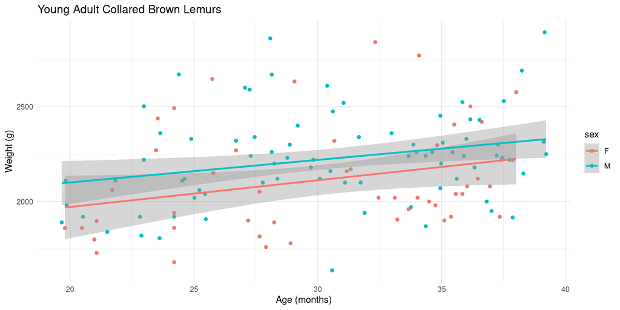

Age vs weight of Young Adult Collared Brown Lemurs

## Inline code

````markdown
```{r}
#| label: biggest_lemur
big_lemur = lemurs %>%
  slice_max(weight_g, n = 1)
```
````

We can also include code inline, rather than as a separate chunk.

The largest lemur recorded is called `` `r str_to_title(big_lemur$name)` ``, who weighed `` `r format(big_lemur$weight_g, scientific = FALSE)` `` grams.

The largest lemur recorded is called Sabina, who weighed 10337 grams.

## Task 2: Adding code

- Try to render the document, what are the problems?
- Add a new code chunk to load the libraries {ggplot2}, {dplyr} and {tidyr}
- Set the code chunk options for your new chunk to the hide the code and messages
- Add a caption to the plot with the `fig-cap` code chunk option
- Add a code chunk to fit a linear model `fit = lm(weight_g ~ age_at_wt_mo, data = df)`
- Use inline code chunks to give the model fit coefficients in the sentence. Hint: `fit$coefficients`

`15:00`

# Equations, journals, referencing and more…

## Equations

We can use LaTeX to add equations.

```latex
\begin{equation}
\hat{e}_i = Y_i - \hat{Y}_i
\end{equation}
```

$$\begin{equation}
\hat{e}_i = Y_i - \hat{Y}_i
\end{equation}$$

## Styling

Correctly formatted journal articles in 30 seconds?

Try [quarto-journals](https://github.com/quarto-journals/) e.g. for a Journal of Statistical Software article:

```yaml
----
title: "My Document"
format:
  pdf: default
  jss-pdf:
    keep-tex: true
---
```

## Referencing

Create a reference file:

```latex
@article{Andriambeloson2020,
  title={Prolonged torpor in Goodman’s mouse lemurs (Microcebus lehilahytsara) from the high-altitude forest of Tsinjoarivo, central-eastern Madagascar.},
  author={Andriambeloson JB, Greene LK, Blanco MB},
  journal={Folia Primatologica},
  volume={91},
  pages={697–710},
  year={2020}
}
```

Add a link to your reference file in your .qmd document YAML:

```yaml
bibliography: references.bib
```

Then link the reference using an @.

To cite a paper about lemurs `[@Andriambeloson2020]`

## Task 3: Getting paper ready

- Open `task-3.qmd`
- Add the equation for linear regression `y = mx + c` in
- Link to the `reference.bib` file in your `.qmd` document YAML header
- Fix the reference link using an `@`.

`15:00`

## Links & Resources

- Quarto docs: [quarto.org](https://quarto.org/)
- RStudio Workshop: [jthomasmock.github.io/quarto-2hr-webinar](https://jthomasmock.github.io/quarto-2hr-webinar/)
- Our [training courses](https://www.jumpingrivers.com/training/all-courses/)

[figure not shown]